# R - Projekt

Highest Mountains

Iva Bokšić

22.1.2021.

Učitavanje dataframe u varijablu data.

```r
data <- read.csv("HighestMountains.csv",encoding = 'UTF-8')
head(data)
```

|  | Rank | Mountain | Height..m. | Height..ft. | Prominence..m. | Range | Coordinates | Parent.mountain | First.ascent | Ascents.bef..2004 | Failed.attempts.bef..2004 |
| --- | --- | --- | --- | --- | --- | --- | --- | --- | --- | --- | --- |
| 1 | 1 | Mount Everest / Sagarmatha / Chomolungma | 8848 | 29029 | 8848 | Mahalangur Himalaya | 27°59'17"N 86°55'31"E |  | 1953 | >>145 | 121 |
| 2 | 2 | K2 / Qogir / Godwin Austen | 8611 | 28251 | 4017 | Baltoro Karakoram | 35°52'53"N 76°30'48"E | Mount Everest | 1954 | 45 | 44 |
| 3 | 3 | Kangchenjunga | 8586 | 28169 | 3922 | Kangchenjunga Himalaya | 27°42'12"N 88°08'51"E | Mount Everest | 1955 | 38 | 24 |
| 4 | 4 | Lhotse | 8516 | 27940 | 610 | Mahalangur Himalaya | 27°57'42"N 86°55'59"E | Mount Everest | 1956 | 26 | 26 |
| 5 | 5 | Makalu | 8485 | 27838 | 2386 | Mahalangur Himalaya | 27°53'23"N 87°05'20"E | Mount Everest | 1955 | 45 | 52 |
| 6 | 6 | Cho Oyu | 8188 | 26864 | 2340 | Mahalangur Himalaya | 28°05'39"N 86°39'39"E | Mount Everest | 1954 | 79 | 28 |

Podaci dataframe-a su podijeljeni u 118 redaka i 11 stupaca.

```r
dim(data)
```

```
## [1] 118  11
```

Nazivi stupaca su :

```r
names(data)
```

```
##  [1] "Rank"                      "Mountain"
##  [3] "Height..m."                "Height..ft."
##  [5] "Prominence..m."            "Range"
##  [7] "Coordinates"               "Parent.mountain"
##  [9] "First.ascent"              "Ascents.bef..2004"
## [11] "Failed.attempts.bef..2004"
```

Vidimo da se nazivi stupaca razlikuju u odnosu na csv dokument.

Preimenovanje stupaca da odgovara csv-u.

```r
names(data)[names(data) == "Failed.attempts.bef..2004"] <- "Failed attempts bef. 2004."
names(data)[names(data) == "Height..m."] <- "Height (m)"
names(data)[names(data) == "Height..ft."] <- "Height (ft)"
names(data)[names(data) == "Prominence..m."] <- "Prominence (m)"
names(data)[names(data) == "Parent.mountain"] <- "Parent mountain"
names(data)[names(data) == "First.ascent"] <- "First ascent"
names(data)[names(data) == "Ascents.bef..2004"] <- "Ascents bef. 2004."
```

Nova imena stupaca su:

```r
names(data)
```

```
##  [1] "Rank"                       "Mountain"
##  [3] "Height (m)"                 "Height (ft)"
##  [5] "Prominence (m)"             "Range"
##  [7] "Coordinates"                "Parent mountain"
##  [9] "First ascent"               "Ascents bef. 2004."
## [11] "Failed attempts bef. 2004."
```

##Opis dataframa

**Rank**

- Pozicija planinskog vrha s obzirom na visinu.

**Mountain**

- Ime planinskog vrha.
- U slučaju više imena međusobno su odvojeni s “/”.

**Height (m)**

- Visina planinskog vrha izražena u metrima.

**Height (ft)**

- Visina planinskog vrha izražena u stopama.

**Prominence (m)**

- Prominencija planine izražena u metrima

**Range**

- Planinski lanac kojem planinski vrh pripada.

**Coordinates**

- Koordinate vrha.

**Parent mountain**

- Roditeljska planina

**First ascent**

- Godina prvog penjanja na vrha.

**Ascents bef. 2004**

- Broj uspješnih penjanja prije 2004. godine.

**Failed attempts bef. 2004:**

- Broj neuspješnih penjanja prije 2004. godine.

Struktura dataframe je:

```r
str(data)
```

```
## 'data.frame':    118 obs. of  11 variables:
##  $ Rank                      : int  1 2 3 4 5 6 7 8 9 10 ...
##  $ Mountain                  : chr  "Mount Everest / Sagarmatha / Chomolungma" "K2 / Qogir / Godwin Austen" "Kangchenjunga" "Lhotse" ...
##  $ Height (m)                : int  8848 8611 8586 8516 8485 8188 8167 8163 8126 8091 ...
##  $ Height (ft)               : int  29029 28251 28169 27940 27838 26864 26795 26781 26660 26545 ...
##  $ Prominence (m)            : int  8848 4017 3922 610 2386 2340 3357 3092 4608 2984 ...
##  $ Range                     : chr  "Mahalangur Himalaya" "Baltoro Karakoram" "Kangchenjunga Himalaya" "Mahalangur Himalaya" ...
##  $ Coordinates               : chr  "27°59'17\"N 86°55'31\"E " "35°52'53\"N 76°30'48\"E " "27°42'12\"N 88°08'51\"E " "27°57'42\"N 86°55'59\"E " ...
##  $ Parent mountain           : chr  "" "Mount Everest" "Mount Everest" "Mount Everest" ...
##  $ First ascent              : chr  "1953" "1954" "1955" "1956" ...
##  $ Ascents bef. 2004.        : chr  ">>145 " "45" "38" "26" ...
##  $ Failed attempts bef. 2004.: int  121 44 24 26 52 28 39 45 67 47 ...
```

Stupac Ascents.bef..2004 nije Integer i moramo ga pretvoriti da bi mogli raditi analize vezane za broj uspješnih i neuspješnih penjanja.

```r
data$`Ascents bef. 2004.` <- as.numeric(data$`Ascents bef. 2004.`)
```

Dataframe sadržđi 4 NA vrijednosti.

```r
sum(!complete.cases(data))
```

```
## [1] 4
```

Prilikom pretvrobe vidimo da su pojednini stupci NA vrijednost, jer nisu sadržavali podatak o uspješnim penjanjima ili je taj podatak bio neprecizan. Takve planinske vrhove nećemo koristiti pri analizi vezanoj za broj uspješnih i neuspješnih penjanja.

```r
na <- data[is.na(data$`Ascents bef. 2004.`),]
na
```

|  | Rank | Mountain | Height (m) | Height (ft) | Prominence (m) | Range | Coordinates | Parent mountain | First ascent | Ascents bef. 2004. | Failed attempts bef. 2004. |
| --- | --- | --- | --- | --- | --- | --- | --- | --- | --- | --- | --- |
| 1 | 1 | Mount Everest / Sagarmatha / Chomolungma | 8848 | 29029 | 8848 | Mahalangur Himalaya | 27°59'17"N 86°55'31"E |  | 1953 | NA | 121 |
| 48 | 43 | Muztagh Ata | 7546 | 24757 | 2735 | Muztagata (Eastern Pamirs) | 38°16'33"N 75°06'58"E | Kongur Tagh | 1956 | NA | NA |
| 55 | 50 | Ismoil Somoni Peak | 7495 | 24590 | 3402 | Pamir (Akademiya Nauk Range) | 38°56'35"N 72°00'57"E | Muztagh Ata | 1933 | NA | NA |
| 65 | 60 | Jengish Chokusu / Tömür / Pk Pobeda | 7439 | 24406 | 4148 | Tian Shan | 42°02'05"N 80°07'47"E | Ismail Samani Peak | 1938 | NA | NA |

Izbacivanje NA vrijednosti i kreiranje novog dataframe.

```r
dataAnalize <- data
dataAnalize <- dataAnalize[!dataAnalize$Rank==1 &
                          !dataAnalize$Rank==43 &
                          !dataAnalize$Rank==50 &
                          !dataAnalize$Rank==60,]
head(dataAnalize)
```

|  | Rank | Mountain | Height (m) | Height (ft) | Prominence (m) | Range | Coordinates | Parent mountain | First ascent | Ascents bef. 2004. | Failed attempts bef. 2004. |
| --- | --- | --- | --- | --- | --- | --- | --- | --- | --- | --- | --- |
| 2 | 2 | K2 / Qogir / Godwin Austen | 8611 | 28251 | 4017 | Baltoro Karakoram | 35°52'53"N 76°30'48"E | Mount Everest | 1954 | 45 | 44 |
| 3 | 3 | Kangchenjunga | 8586 | 28169 | 3922 | Kangchenjunga Himalaya | 27°42'12"N 88°08'51"E | Mount Everest | 1955 | 38 | 24 |
| 4 | 4 | Lhotse | 8516 | 27940 | 610 | Mahalangur Himalaya | 27°57'42"N 86°55'59"E | Mount Everest | 1956 | 26 | 26 |
| 5 | 5 | Makalu | 8485 | 27838 | 2386 | Mahalangur Himalaya | 27°53'23"N 87°05'20"E | Mount Everest | 1955 | 45 | 52 |
| 6 | 6 | Cho Oyu | 8188 | 26864 | 2340 | Mahalangur Himalaya | 28°05'39"N 86°39'39"E | Mount Everest | 1954 | 79 | 28 |
| 7 | 7 | Dhaulagiri I | 8167 | 26795 | 3357 | Dhaulagiri Himalaya | 28°41'48"N 83°29'35"E | K2 | 1960 | 51 | 39 |

```r
str(dataAnalize)
```

```
## 'data.frame':    114 obs. of  11 variables:
##  $ Rank                      : int  2 3 4 5 6 7 8 9 10 11 ...
##  $ Mountain                  : chr  "K2 / Qogir / Godwin Austen" "Kangchenjunga" "Lhotse" "Makalu" ...
##  $ Height (m)                : int  8611 8586 8516 8485 8188 8167 8163 8126 8091 8080 ...
##  $ Height (ft)               : int  28251 28169 27940 27838 26864 26795 26781 26660 26545 26509 ...
##  $ Prominence (m)            : int  4017 3922 610 2386 2340 3357 3092 4608 2984 2155 ...
##  $ Range                     : chr  "Baltoro Karakoram" "Kangchenjunga Himalaya" "Mahalangur Himalaya" "Mahalangur Himalaya" ...
##  $ Coordinates               : chr  "35°52'53\"N 76°30'48\"E " "27°42'12\"N 88°08'51\"E " "27°57'42\"N 86°55'59\"E " "27°53'23\"N 87°05'20\"E " ...
##  $ Parent mountain           : chr  "Mount Everest" "Mount Everest" "Mount Everest" "Mount Everest" ...
##  $ First ascent              : chr  "1954" "1955" "1956" "1955" ...
##  $ Ascents bef. 2004.        : num  45 38 26 45 79 51 49 52 36 31 ...
##  $ Failed attempts bef. 2004.: int  44 24 26 52 28 39 45 67 47 16 ...
```

Novi dataframe **dataAnalize** ne sadržava NA vrijednosti.

```r
sum(!complete.cases(dataAnalize))
```

```
## [1] 0
```

Planinski lanci na kojima se nalaze najviše planine su :

```r
unique(data$Range)
```

```
##  [1] "Mahalangur Himalaya"          "Baltoro Karakoram"
##  [3] "Kangchenjunga Himalaya"       "Dhaulagiri Himalaya"
##  [5] "Manaslu Himalaya"             "Nanga Parbat Himalaya"
##  [7] "Annapurna Himalaya"           "Jugal Himalaya"
##  [9] "Hispar Karakoram"             "Masherbrum Karakoram"
## [11] "Garhwal Himalaya"             "Batura Karakoram"
## [13] "Rakaposhi-Haramosh Karakoram" "Assam Himalaya"
## [15] "Saltoro Karakoram"            "Hindu Kush"
## [17] "Langtang Himalaya"            "Nalakankar Himalaya"
## [19] "Saser Karakoram"              "Kongur Shan (Eastern Pamirs)"
## [21] "Kula Kangri Himalaya"         "Daxue Shan (Hengduan Shan)"
## [23] "Muztagata (Eastern Pamirs)"   "Rimo Karakoram"
## [25] "Pamir (Akademiya Nauk Range)" "Siachen Karakoram"
## [27] "Tian Shan"                    "Ganesh Himalaya"
## [29] "Labuche Himalaya"             "Jomolhari Himalaya"
## [31] "Yengisogat Karakoram"         "Panmah Karakoram"
## [33] "Baiku Himalaya"               "Lunana Himalaya"
## [35] "Nagarze Himalaya"
```

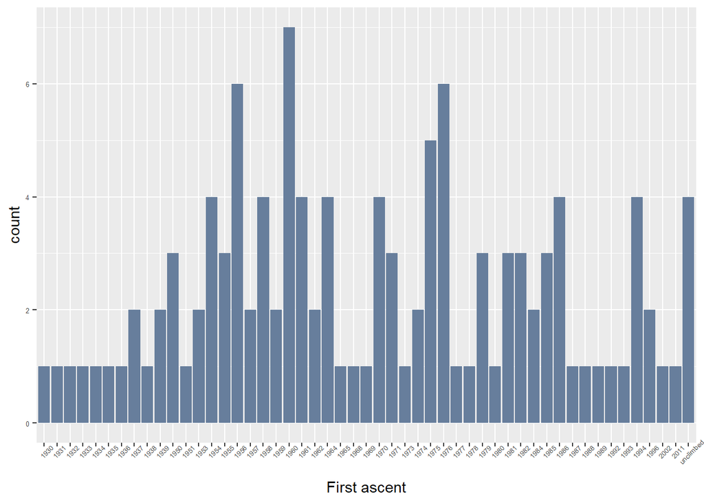

```r
ggplot(data,aes(x=`First ascent`))+geom_bar(fill = "#677e9c")+theme(axis.text=element_text(size=5),axis.text.x=element_text(angle=45))
```

```r
unclimbed <- data[data$`First ascent`=="unclimbed",]
unclimbed
```

|  | Rank | Mountain | Height (m) | Height (ft) | Prominence (m) | Range | Coordinates | Parent mountain | First ascent | Ascents bef. 2004. | Failed attempts bef. 2004. |
| --- | --- | --- | --- | --- | --- | --- | --- | --- | --- | --- | --- |
| 45 | 40 | Gangkhar Puensum | 7570 | 24836 | 2995 | Kula Kangri Himalaya | 28°02'50"N 90°27'19"E | Kangchenjunga | unclimbed | 0 | 3 |
| 103 | 94 | Labuche Kang III / East | 7250 | 23786 | 570 | Labuche Himalaya | 28°18'05"N 86°23'02"E | Labuche Kang | unclimbed | 0 | 0 |
| 109 | 100 | Karjiang | 7221 | 23691 | 880 | Kula Kangri Himalaya | 28°15'27"N 90°38'49"E | Kula Kangri | unclimbed | 0 | 2 |
| 112 | 103 | Tongshanjiabu | 7207 | 23645 | 1757 | Lunana Himalaya | 28°11'12"N 89°57'27"E | Gangkar Puensum | unclimbed | 0 | 0 |

Grupiramo li planinske vrhove po planinskim lancima i prebrojimo li njihov broj u pojedinom planinskom lancu dobivamo histogram:

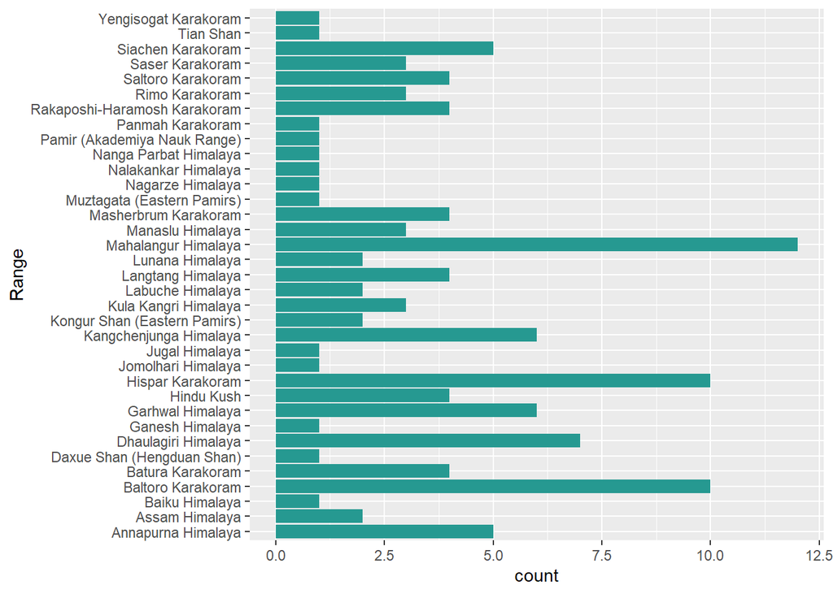

```r
ggplot(data,aes(x=Range))+geom_bar(fill = "#269991")+coord_flip()
```

Iz histograma možemo vidjeti da se 12 najviših planinskih vrhova od 118 u dataframu nalazi u **Mahalangur Himalaya** planinskom lancu. Planinski lanci Baltoro Karakoram i Hispar Karakoram imaju 10 vrhova među najvišljim u svijetu.

Prvih 14 najviših planinskih vrhova su višlji od 8000 metara. Planinski vrhovi su poredani po visini i vidimo da je Mount Everest najvišlja vrh na svijetu.

```r
over8000 <- data[data$`Height (m)`>=8000,]
over8000
```

|  | Rank | Mountain | Height (m) | Height (ft) | Prominence (m) | Range | Coordinates | Parent mountain | First ascent | Ascents bef. 2004. | Failed attempts bef. 2004. |
| --- | --- | --- | --- | --- | --- | --- | --- | --- | --- | --- | --- |
| 1 | 1 | Mount Everest / Sagarmatha / Chomolungma | 8848 | 29029 | 8848 | Mahalangur Himalaya | 27°59'17"N 86°55'31"E |  | 1953 | NA | 121 |
| 2 | 2 | K2 / Qogir / Godwin Austen | 8611 | 28251 | 4017 | Baltoro Karakoram | 35°52'53"N 76°30'48"E | Mount Everest | 1954 | 45 | 44 |
| 3 | 3 | Kangchenjunga | 8586 | 28169 | 3922 | Kangchenjunga Himalaya | 27°42'12"N 88°08'51"E | Mount Everest | 1955 | 38 | 24 |
| 4 | 4 | Lhotse | 8516 | 27940 | 610 | Mahalangur Himalaya | 27°57'42"N 86°55'59"E | Mount Everest | 1956 | 26 | 26 |
| 5 | 5 | Makalu | 8485 | 27838 | 2386 | Mahalangur Himalaya | 27°53'23"N 87°05'20"E | Mount Everest | 1955 | 45 | 52 |
| 6 | 6 | Cho Oyu | 8188 | 26864 | 2340 | Mahalangur Himalaya | 28°05'39"N 86°39'39"E | Mount Everest | 1954 | 79 | 28 |
| 7 | 7 | Dhaulagiri I | 8167 | 26795 | 3357 | Dhaulagiri Himalaya | 28°41'48"N 83°29'35"E | K2 | 1960 | 51 | 39 |
| 8 | 8 | Manaslu | 8163 | 26781 | 3092 | Manaslu Himalaya | 28°33'00"N 84°33'35"E | Cho Oyu | 1956 | 49 | 45 |
| 9 | 9 | Nanga Parbat | 8126 | 26660 | 4608 | Nanga Parbat Himalaya | 35°14'14"N 74°35'21"E | Dhaulagiri | 1953 | 52 | 67 |
| 10 | 10 | Annapurna I | 8091 | 26545 | 2984 | Annapurna Himalaya | 28°35'44"N 83°49'13"E | Cho Oyu | 1950 | 36 | 47 |

[output cut: 4 more lines]

Analiza visine planinskih vrhova.

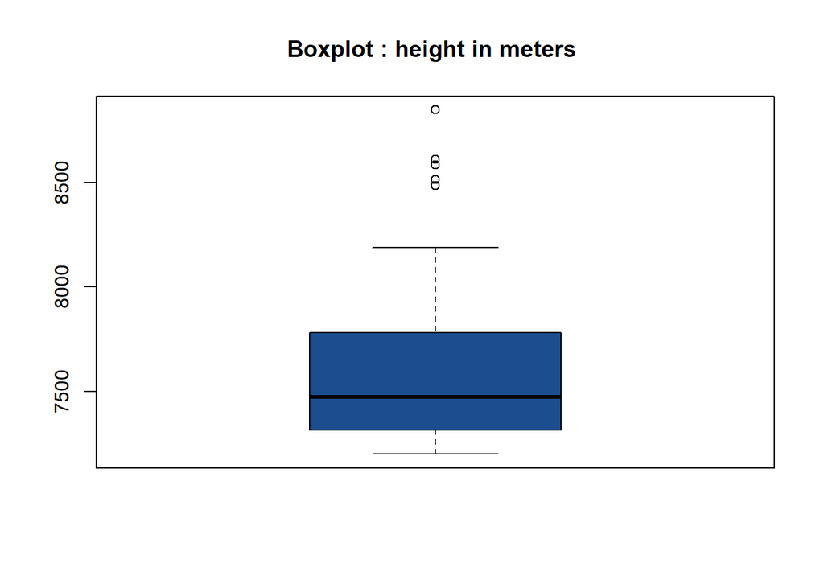

```r
boxplot(data$`Height (m)`,
        names = c('Height in meters'),
        main='Boxplot : height in meters ',
        col=("#1b4d8f"))
```

```r
summary(data$`Height (m)`)
```

```
##    Min. 1st Qu.  Median    Mean 3rd Qu.    Max.
##    7200    7316    7472    7578    7776    8848
```

Srednja vrijednost, najveća i najmanja visina planinskih vrhova grupiranih po planinskim lancima.

```r
data %>% group_by(Range) %>%
  summarize(mean_height = round(mean(`Height (m)`, na.rm = TRUE),2),
            max_height= max(`Height (m)`, na.rm = TRUE),
            min_height= min(`Height (m)`, na.rm = TRUE)) -> heightData
heightData
```

| Range | mean_height | max_height | min_height |
| --- | --- | --- | --- |
| Annapurna Himalaya | 7651.40 | 8091 | 7219 |
| Assam Himalaya | 7538.00 | 7782 | 7294 |
| Baiku Himalaya | 7281.00 | 7281 | 7281 |
| Baltoro Karakoram | 7820.10 | 8611 | 7276 |
| Batura Karakoram | 7567.50 | 7795 | 7388 |
| Daxue Shan (Hengduan Shan) | 7556.00 | 7556 | 7556 |
| Dhaulagiri Himalaya | 7585.14 | 8167 | 7246 |
| Ganesh Himalaya | 7422.00 | 7422 | 7422 |
| Garhwal Himalaya | 7479.17 | 7816 | 7242 |
| Hindu Kush | 7488.00 | 7708 | 7349 |

[output cut: 25 more lines]

U dataframe se dodaje postotak neuspješnosti penjanja za pojedini vrh tako da se broj neupješnih penjanja podijeli s brojem uspješnih i neupješnih penjanja.

```r
dataAnalize$`Failed attempts (%)` <-
  round(dataAnalize$`Failed attempts bef. 2004.`/
  (dataAnalize$`Failed attempts bef. 2004.`+dataAnalize$`Ascents bef. 2004.`)*100,2)
head(dataAnalize)
```

|  | Rank | Mountain | Height (m) | Height (ft) | Prominence (m) | Range | Coordinates | Parent mountain | First ascent | Ascents bef. 2004. | Failed attempts bef. 2004. | Failed attempts (%) |
| --- | --- | --- | --- | --- | --- | --- | --- | --- | --- | --- | --- | --- |
| 2 | 2 | K2 / Qogir / Godwin Austen | 8611 | 28251 | 4017 | Baltoro Karakoram | 35°52'53"N 76°30'48"E | Mount Everest | 1954 | 45 | 44 | 49.44 |
| 3 | 3 | Kangchenjunga | 8586 | 28169 | 3922 | Kangchenjunga Himalaya | 27°42'12"N 88°08'51"E | Mount Everest | 1955 | 38 | 24 | 38.71 |
| 4 | 4 | Lhotse | 8516 | 27940 | 610 | Mahalangur Himalaya | 27°57'42"N 86°55'59"E | Mount Everest | 1956 | 26 | 26 | 50.00 |
| 5 | 5 | Makalu | 8485 | 27838 | 2386 | Mahalangur Himalaya | 27°53'23"N 87°05'20"E | Mount Everest | 1955 | 45 | 52 | 53.61 |
| 6 | 6 | Cho Oyu | 8188 | 26864 | 2340 | Mahalangur Himalaya | 28°05'39"N 86°39'39"E | Mount Everest | 1954 | 79 | 28 | 26.17 |
| 7 | 7 | Dhaulagiri I | 8167 | 26795 | 3357 | Dhaulagiri Himalaya | 28°41'48"N 83°29'35"E | K2 | 1960 | 51 | 39 | 43.33 |

## Test o dvije proporcije

### Usporedba planinskih lanaca : “Kangchenjunga Himalaya” i “Garhwal Himalaya”

H0: neuspjela penjanja su jednako ili više zastupljena u “Kangchenjunga Himalaya” nego “Kangchenjunga Himalaya”  
H1: neuspjela penjanja su manje zastupljena u “Kangchenjunga Himalaya” nego “Kangchenjunga Himalaya”

```r
KangchenjungaHimalaya <- dataAnalize[dataAnalize$Range=="Kangchenjunga Himalaya", ]
KangchenjungaHimalaya
```

|  | Rank | Mountain | Height (m) | Height (ft) | Prominence (m) | Range | Coordinates | Parent mountain | First ascent | Ascents bef. 2004. | Failed attempts bef. 2004. | Failed attempts (%) |
| --- | --- | --- | --- | --- | --- | --- | --- | --- | --- | --- | --- | --- |
| 3 | 3 | Kangchenjunga | 8586 | 28169 | 3922 | Kangchenjunga Himalaya | 27°42'12"N 88°08'51"E | Mount Everest | 1955 | 38 | 24 | 38.71 |
| 34 | 32 | Jannu | 7711 | 25299 | 1036 | Kangchenjunga Himalaya | 27°40'56"N 88°02'40"E | Kangchenjunga | 1962 | 17 | 12 | 41.38 |
| 62 | 57 | Jongsong Peak | 7462 | 24482 | 1298 | Kangchenjunga Himalaya | 27°52'54"N 88°08'09"E | Kangchenjunga | 1930 | 2 | 3 | 60.00 |
| 71 | 65 | Kabru N | 7412 | 24318 | 780 | Kangchenjunga Himalaya | 27°38'02"N 88°07'00"E | Kangchenjunga | 1994 | 1 | 2 | 66.67 |
| 82 | 76 | Kirat Chuli | 7362 | 24153 | 1168 | Kangchenjunga Himalaya | 27°47'16"N 88°11'43"E | Kangchenjunga | 1939 | 1 | 6 | 85.71 |
| 85 | 117 | Gimmigela / The Twins | 7350 | 24114 | 432 | Kangchenjunga Himalaya | 27°44'27"N 88°09'31"E | Kangchenjunga | 1994 | 3 | 1 | 25.00 |

```r
GarhwalHimalaya <- dataAnalize[dataAnalize$Range=="Garhwal Himalaya", ]
GarhwalHimalaya
```

|  | Rank | Mountain | Height (m) | Height (ft) | Prominence (m) | Range | Coordinates | Parent mountain | First ascent | Ascents bef. 2004. | Failed attempts bef. 2004. | Failed attempts (%) |
| --- | --- | --- | --- | --- | --- | --- | --- | --- | --- | --- | --- | --- |
| 25 | 23 | Nanda Devi | 7816 | 25643 | 3139 | Garhwal Himalaya | 30°22'33"N 79°58'15"E | Dhaulagiri | 1936 | 14 | 12 | 46.15 |
| 31 | 29 | Kamet | 7756 | 25446 | 2825 | Garhwal Himalaya | 30°55'12"N 79°35'30"E | Nanda Devi | 1931 | 23 | 14 | 37.84 |
| 66 | 115 | Sunanda Devi | 7434 | 24390 | 260 | Garhwal Himalaya | 30°22'00"N 79°59'40"E | Nanda Devi | 1939 | 14 | 12 | 46.15 |
| 83 | 116 | Abi Gamin | 7355 | 24131 | 217 | Garhwal Himalaya | 30°55'57"N 79°36'09"E | Kamet | 1950 | 17 | 2 | 10.53 |
| 100 | 92 | Mana Peak | 7272 | 23858 | 730 | Garhwal Himalaya | 30°52'50"N 79°36'55"E | Kamet | 1937 | 7 | 3 | 30.00 |
| 106 | 97 | Mukut Parbat | 7242 | 23760 | 840 | Garhwal Himalaya | 30°56'57"N 79°34'12"E | Kamet | 1951 | 2 | 1 | 33.33 |

Zbraja se ukupan broj neuspješnih i uspješnih penjanja za Kangchenjunga Himalaya i Garhwal Himalaya.

```r
sumFailedKangchenjunga <-
  sum(dataAnalize[dataAnalize$Range=="Kangchenjunga Himalaya", ]$`Failed attempts bef. 2004.`)
sumFailedKangchenjunga
```

```
## [1] 48
```

```r
sumSuccKangchenjunga <-
  sum(dataAnalize[dataAnalize$Range=="Kangchenjunga Himalaya", ]$`Ascents bef. 2004.`)
sumSuccKangchenjunga
```

```
## [1] 62
```

```r
sumFailedGarhwal <-
  sum(dataAnalize[dataAnalize$Range=="Garhwal Himalaya", ]$`Failed attempts bef. 2004.`)
sumFailedGarhwal
```

```
## [1] 44
```

```r
sumSuccGarhwal <-
  sum(dataAnalize[dataAnalize$Range=="Garhwal Himalaya", ]$`Ascents bef. 2004.`)
sumSuccGarhwal
```

```
## [1] 77
```

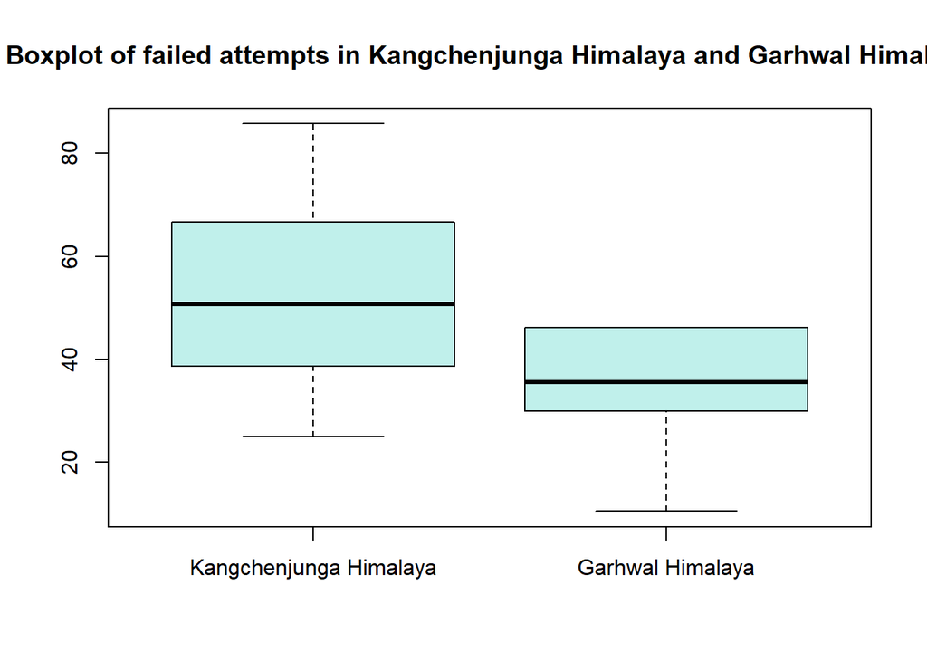

Testiranje proporcija neuspješnjosti penjanja.

```r
failedAttempts <- c(sumFailedKangchenjunga,sumFailedGarhwal)
attempts <- c(sumFailedKangchenjunga+sumSuccKangchenjunga,sumSuccGarhwal+sumFailedGarhwal)

prop.test(failedAttempts, attempts,
          alternative = c("less"),
          conf.level = 0.95)
```

```
##
##  2-sample test for equality of proportions with continuity correction
##
## data:  failedAttempts out of attempts
## X-squared = 0.98633, df = 1, p-value = 0.8397
## alternative hypothesis: less
## 95 percent confidence interval:
##  -1.0000000  0.1873462
## sample estimates:
##    prop 1    prop 2
## 0.4363636 0.3636364
```

Rezultat : P vrijednost provedenog testa iznosi 0.8397 uz 95% interval pouzdanosti.

p-vrijednost > α **H0 se prihvaća**.

Veću zastupljenost neuspjelih penjanja u “Kangchenjunga Himalaya” nego “Garhwal Himalaya” možemo iščitati iz usporedbe proporcija na testu gdje je ta razlika oko 7% veća u korist “Kangchenjunga Himalaya”.

## Test homogenosti

```r
sumFailedBaltoro <-
  sum(dataAnalize[dataAnalize$Range=="Baltoro Karakoram", ]$`Failed attempts bef. 2004.`)
sumFailedBaltoro
```

```
## [1] 110
```

```r
sumSuccBaltoro <-
  sum(dataAnalize[dataAnalize$Range=="Baltoro Karakoram", ]$`Ascents bef. 2004.`)
sumSuccBaltoro
```

```
## [1] 183
```

```r
sumFailedMahalangur <-
  sum(dataAnalize[dataAnalize$Range=="Mahalangur Himalaya", ]$`Failed attempts bef. 2004.`)
sumFailedMahalangur
```

```
## [1] 134
```

```r
sumSuccMahalangur <-
  sum(dataAnalize[dataAnalize$Range=="Mahalangur Himalaya", ]$`Ascents bef. 2004.`)
sumSuccMahalangur
```

```
## [1] 185
```

```r
sumFailedHispar <-
  sum(dataAnalize[dataAnalize$Range=="Hispar Karakoram", ]$`Failed attempts bef. 2004.`)
sumFailedHispar
```

```
## [1] 27
```

```r
sumSuccHispar <-
  sum(dataAnalize[dataAnalize$Range=="Hispar Karakoram", ]$`Ascents bef. 2004.`)
sumSuccHispar
```

```
## [1] 19
```

```r
attempts <- data.frame(range =
            c("Mahalangur Himalaya","Baltoro Karakoram","Hispar Karakoram",""),

  `successful attempts` = c(sumSuccMahalangur,
                                        sumSuccBaltoro,
                                        sumSuccHispar,
                                        sumSuccMahalangur+sumSuccBaltoro+sumSuccHispar),


`failed attempts` = c(sumFailedMahalangur,
                    sumFailedBaltoro,
                    sumFailedHispar,
                    sumFailedMahalangur+sumFailedBaltoro+sumFailedHispar),
`all attempts` = c(sumFailedMahalangur+sumSuccMahalangur,
                    sumFailedBaltoro+sumSuccBaltoro,
                    sumFailedHispar+sumSuccHispar,
                    sumFailedMahalangur+sumFailedBaltoro+sumFailedHispar+
                    sumSuccMahalangur+sumSuccBaltoro+sumSuccHispar))

attempts
```

| range | successful.attempts | failed.attempts | all.attempts |
| --- | --- | --- | --- |
| Mahalangur Himalaya | 185 | 134 | 319 |
| Baltoro Karakoram | 183 | 110 | 293 |
| Hispar Karakoram | 19 | 27 | 46 |
|  | 387 | 271 | 658 |

U kontingencijskoj tablici su prikazani broj uspješnih i neuspješnih penjanja za tri planinska lanca s najvećim brojem vrhova koji su u top 118 u svijetu. Provodi se testiranje hipoteze da su populacijske proporcije izmedu svakog retka/stupca kontingencijske tablice jednake.

To je napravljeno testom homogenosti u kojem su hipoteze:

H0: postotak penjanja koji su uspješno završeni jednak je za sva tri planinska lanca,  
H1: postotak penjanja koji su uspješno završeni nije jednak je za sva tri planinska lanca.

Provodi se Hi-kvadrat test nad podatcima tablice.
$$\tilde{\chi}^2=\frac{1}{d}\sum_{k=1}^{n} \frac{(O_k - E_k)^2}{E_k}$$

```r
chisq <- chisq.test(attempts[1:3,2:3])

chisq
```

```
##
##  Pearson's Chi-squared test
##
## data:  attempts[1:3, 2:3]
## X-squared = 7.5164, df = 2, p-value = 0.02333
```

Zaključak

| attempts | percent | range |
| --- | --- | --- |
| Failed attempts | 0.4200627 | Mahalangur Himalaya |
| Failed attempts | 0.3754266 | Baltoro Karakoram |
| Failed attempts | 0.5869565 | Hispar Karakoram |

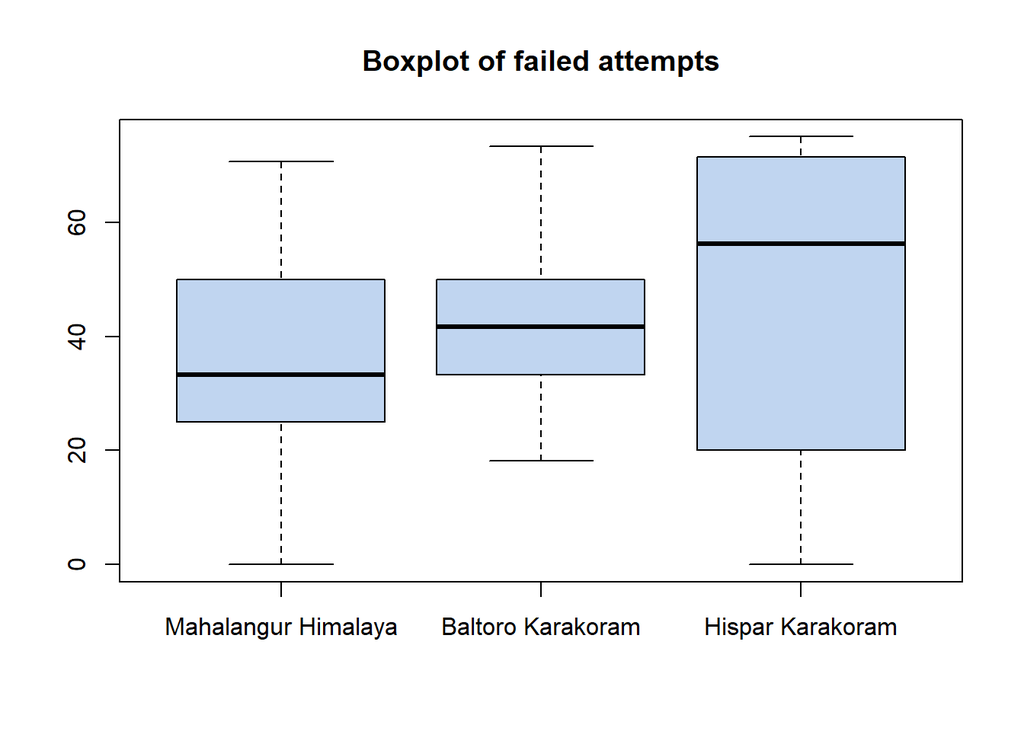

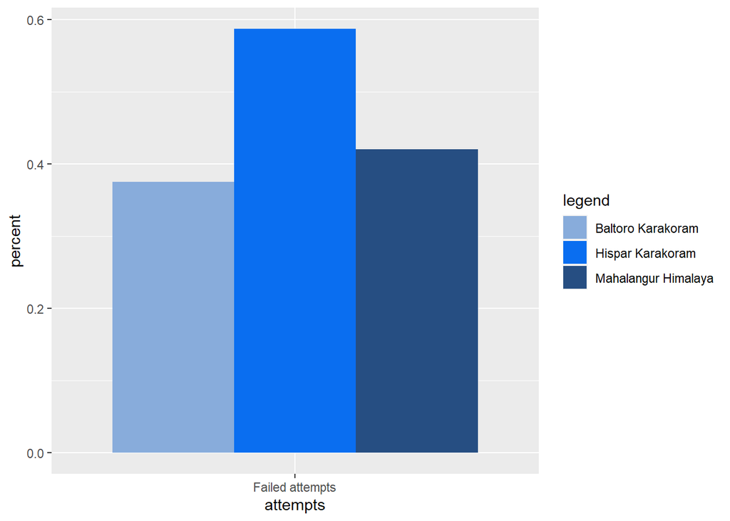

```r
ggplot(proportions) +
  geom_col(
    aes(x = attempts, y = percent, fill = range),
    position = 'dodge') +
   scale_fill_manual("legend", values = c("Mahalangur Himalaya" = "#264e82",
                                          "Baltoro Karakoram" = "#88acdb",
                                          "Hispar Karakoram"="#0a6ef0"))
```

Boxplot i stupčasti dijagram potvrđuju provedbu testa. Uočava se da najveći postotak neuspješnih penjanja ima Hispar Karakoram.

### Linearna regresija

Graf prikazuj međusobnu zavisnost varijabli. Veći i tamniji krugovi predstavljaju veću zavinost,a manji i svijetliji manju.

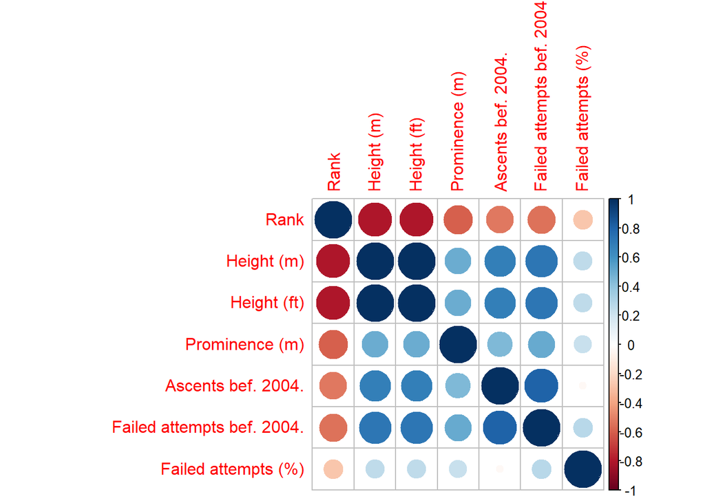

```r
numeric_col <- sapply(dataAnalize, is.numeric)
df_numeric <- dataAnalize[, numeric_col]
Correlation <- cor(df_numeric, use="pairwise.complete.obs")
corrplot(Correlation)
```

Provodi se linearna regresija s obzirom na prikaz grafa tako da se odabiru nezavisni regresori.

```
##
## Call:
## lm(formula = `Ascents bef. 2004.` ~ `Height (m)`, data = dataAnalize)
##
## Residuals:
##     Min      1Q  Median      3Q     Max
## -18.561  -6.686  -0.217   3.533  51.038
##
## Coefficients:
##                Estimate Std. Error t value Pr(>|t|)
## (Intercept)  -2.225e+02  2.342e+01  -9.498 4.77e-16 ***
## `Height (m)`  3.058e-02  3.091e-03   9.893  < 2e-16 ***
## ---
## Signif. codes:  0 '***' 0.001 '**' 0.01 '*' 0.05 '.' 0.1 ' ' 1
##
## Residual standard error: 10.71 on 112 degrees of freedom
## Multiple R-squared:  0.4663, Adjusted R-squared:  0.4616
## F-statistic: 97.87 on 1 and 112 DF,  p-value: < 2.2e-16
```

```
##
## Call:
## lm(formula = `Ascents bef. 2004.` ~ `Height (m)` + `Prominence (m)`,
##     data = dataAnalize)
##
## Residuals:
##     Min      1Q  Median      3Q     Max
## -19.110  -6.306  -0.867   3.750  51.384
##
## Coefficients:
##                    Estimate Std. Error t value Pr(>|t|)
## (Intercept)      -2.019e+02  2.581e+01  -7.820 3.30e-12 ***
## `Height (m)`      2.744e-02  3.517e-03   7.801 3.64e-12 ***
## `Prominence (m)`  2.058e-03  1.134e-03   1.814   0.0724 .
## ---
## Signif. codes:  0 '***' 0.001 '**' 0.01 '*' 0.05 '.' 0.1 ' ' 1
##
## Residual standard error: 10.6 on 111 degrees of freedom
## Multiple R-squared:  0.4817, Adjusted R-squared:  0.4723
## F-statistic: 51.58 on 2 and 111 DF,  p-value: < 2.2e-16
```

```
##
## Call:
## lm(formula = `Height (m)` ~ `Ascents bef. 2004.` + `Prominence (m)`,
##     data = dataAnalize)
##
## Residuals:
##     Min      1Q  Median      3Q     Max
## -421.56 -165.96  -38.05  113.59  800.43
##
## Coefficients:
##                       Estimate Std. Error t value Pr(>|t|)
## (Intercept)          7.334e+03  3.981e+01 184.211  < 2e-16 ***
## `Ascents bef. 2004.` 1.291e+01  1.654e+00   7.801 3.64e-12 ***
## `Prominence (m)`     7.613e-02  2.390e-02   3.185  0.00188 **
## ---
## Signif. codes:  0 '***' 0.001 '**' 0.01 '*' 0.05 '.' 0.1 ' ' 1
##
## Residual standard error: 229.9 on 111 degrees of freedom
## Multiple R-squared:  0.511,  Adjusted R-squared:  0.5022
## F-statistic:    58 on 2 and 111 DF,  p-value: < 2.2e-16
```

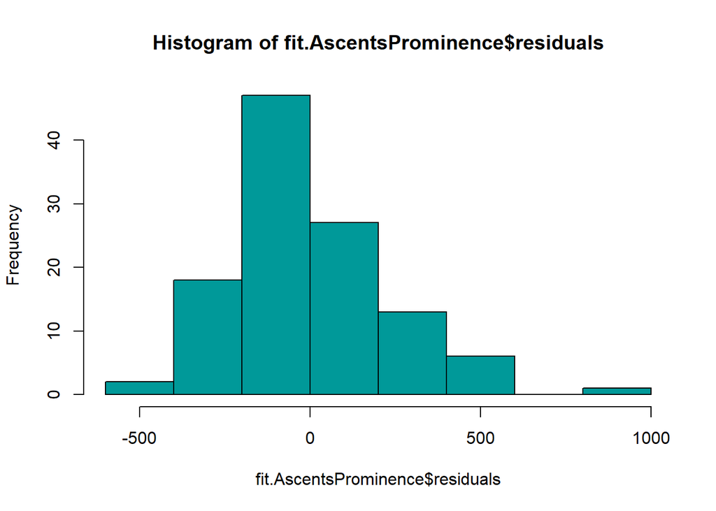

[output not shown]

```r
hist(fit.AscentsProminence$residuals, col="#009999")
```

### Normalnost reziduala

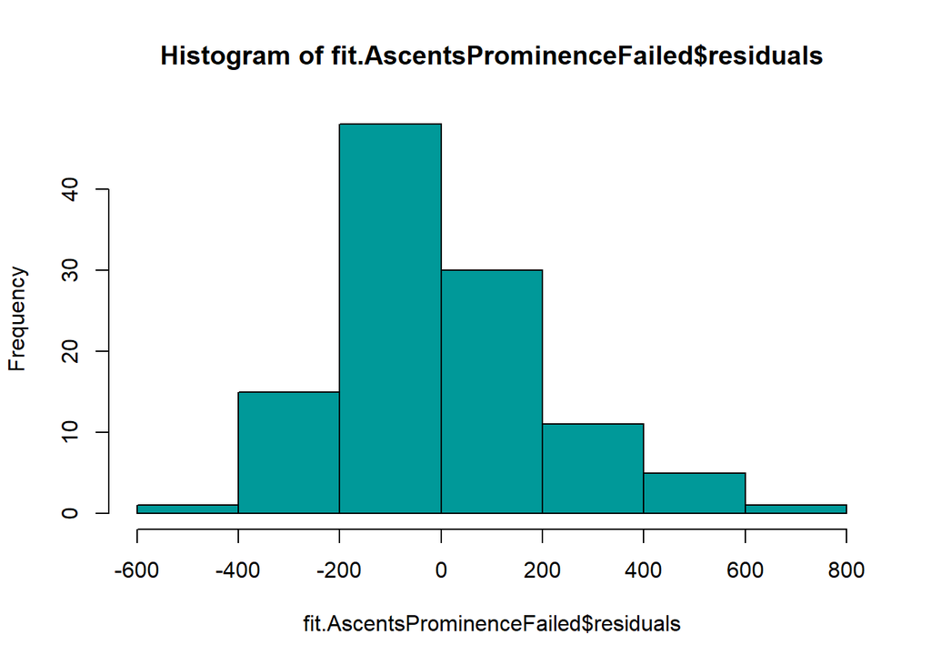

```r
hist(fit.AscentsProminenceFailed$residuals, col="#009999")
```

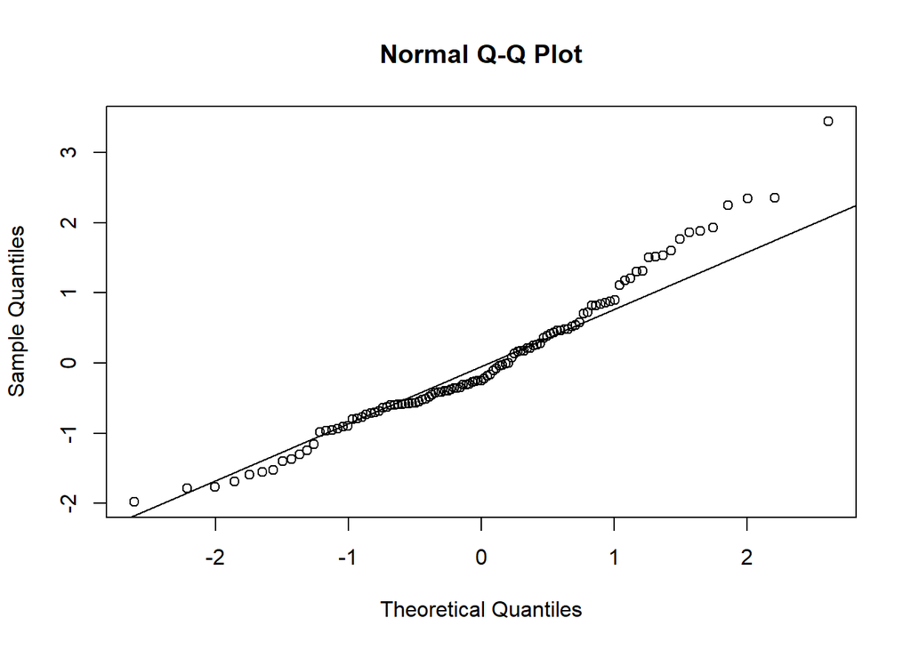

[output not shown]

```r
qqnorm(rstandard(fit.AscentsProminenceFailed))
qqline(rstandard(fit.AscentsProminenceFailed))
```